# R for Reproducible Scientific Analysis

18 January 2017

```r
library(tidyverse)
library(gapminder)
```

# Dataframe Manipulation with `dplyr`

Manipulation of data is important to many researchers. We often select certain observations (rows) or variables (columns), we often group the data by (a) certain variable(s), and calculate summary statistics. Subsetting data sets can be challenging in base R, because there is a fair bit of repetition. Repeating yourself will cost you time, both now and later, and potentially introduce some nasty (silent) errors.

## Key Points

- Use the `dplyr` package to manipulate data
- Use `select()` to choose variables from data
- Use `filter()` to choose observations based on conditions
- Use `group_by()` and `summarize()` to work with subsets of data
- Use `mutate()` to create new variables.

## The `dplyr` package

The `dplyr`(https://cran.r-project.org/web/packages/dplyr/dplyr.pdf) package provides a number of useful functions for manipulating data in a way that will reduce repetition, reduce the probability of making errors, and probably even save some typing. As an added bonus, the `dplyr` grammar is easier to read.

## The pipe `%>%`

We often want to string together a series of `dplyr` functions. This is achieved using `dplyr`’s pipe operator, `%>%`. The pipe used in `tidyverse` comes from `magrittr` package. It takes the value on the left, and passes it as the first argument to the function call on the right. `%>%` isn’t limited to `dplyr` functions. It’s an alternative way of writing any `R` code.

Below is the hypothethical example of baking recipe that utilizes the pipe.

```r
ingridients %>%
  mix() %>%
  pour(into=baking_form) %>%
  put(into=oven) %>%
  bake(time=30) %>%
  slice(pieces=6) %>%
  eat(1)
```

There’s also more traditional, functional way of describing the same process, which would be common in, say base R

```r
eat(
  slice(
    bake(
      put(
       pour(
         mix(ingridients),
        into=baking_form),
       into=oven),
     time=30),
   pieces=6),
  1)
```

Pipes make the same code easier to read. The shortcut to insert the `magrittr` pipe operator `%>%` is `Ctrl`+`Shift`+`M` for Windows/Linux, and `Cmd`+`Shift`+`M` for Mac.

## Using `select()`

If, for example, we wanted to move forward with only a few of the variables of our data, we could use the `select()` function. This will keep only the variables you select.

```r
gapminder %>% select(year, country, gdpPercap)
```

```
## # A tibble: 1,704 x 3
##     year country     gdpPercap
##    <int> <fct>           <dbl>
##  1  1952 Afghanistan      779.
##  2  1957 Afghanistan      821.
##  3  1962 Afghanistan      853.
##  4  1967 Afghanistan      836.
##  5  1972 Afghanistan      740.
##  6  1977 Afghanistan      786.
##  7  1982 Afghanistan      978.
##  8  1987 Afghanistan      852.
##  9  1992 Afghanistan      649.
## 10  1997 Afghanistan      635.
## # … with 1,694 more rows
```

```r
year_country_gdp <- gapminder %>%
  select(year, country, gdpPercap)
year_country_gdp
```

```
## # A tibble: 1,704 x 3
##     year country     gdpPercap
##    <int> <fct>           <dbl>
##  1  1952 Afghanistan      779.
##  2  1957 Afghanistan      821.
##  3  1962 Afghanistan      853.
##  4  1967 Afghanistan      836.
##  5  1972 Afghanistan      740.
##  6  1977 Afghanistan      786.
##  7  1982 Afghanistan      978.
##  8  1987 Afghanistan      852.
##  9  1992 Afghanistan      649.
## 10  1997 Afghanistan      635.
## # … with 1,694 more rows
```

To help you understand why we wrote that in that way, let’s walk through it step by step. First we summon the `gapminder` dataframe and pass it on, using the pipe symbol (`%>%`), to the next step, which is the `select()` function. In this case we don’t specify which data object we use in the `select()` function since in gets that from the previous pipe. Fun fact: There is a good chance you have encountered pipes before in the shell. In `R`, a pipe symbol is `%>%` while in the shell it is `|` but the concept is the same!

## Using `filter()`

The `filter` function is a intuitive way of subsetting data. For example, we can look at the population per continent in 2002:

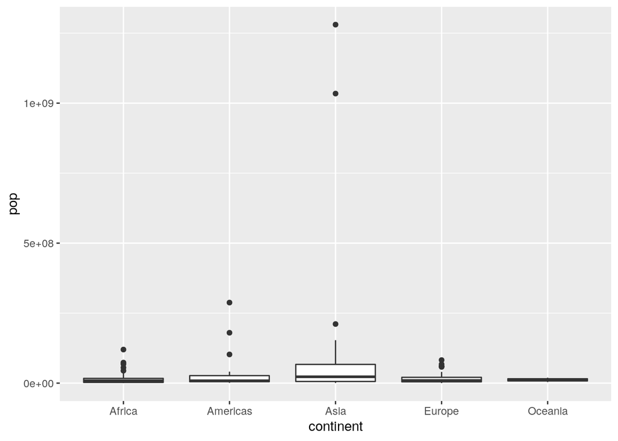

```r
gapminder %>%
  filter(year == 2002) %>%
  ggplot(mapping = aes(x = continent, y = pop)) +
  geom_boxplot()
```

If we now wanted to move forward with the above, but only with European countries, we can combine `select()` and `filter()`:

```r
year_country_gdp_euro <- gapminder %>%
  filter(continent == "Europe") %>%
  select(year, country, gdpPercap)
year_country_gdp_euro
```

```
## # A tibble: 360 x 3
##     year country gdpPercap
##    <int> <fct>       <dbl>
##  1  1952 Albania     1601.
##  2  1957 Albania     1942.
##  3  1962 Albania     2313.
##  4  1967 Albania     2760.
##  5  1972 Albania     3313.
##  6  1977 Albania     3533.
##  7  1982 Albania     3631.
##  8  1987 Albania     3739.
##  9  1992 Albania     2497.
## 10  1997 Albania     3193.
## # … with 350 more rows
```

## **Challenge 1.**

### Assignment

> - Write a single command (which can span multiple lines and includes pipes) that will produce a dataframe that has the Norwegian values for `gdpPercap`, `lifeExp` and `year`, but not for other countries How many rows does your dataframe have and why?

### Solution

```r
country_lifeExp_Norway <- gapminder %>%
  filter(country == "Norway") %>%
  select(year, lifeExp, gdpPercap)
country_lifeExp_Norway
```

```
## # A tibble: 12 x 3
##     year lifeExp gdpPercap
##    <int>   <dbl>     <dbl>
##  1  1952    72.7    10095.
##  2  1957    73.4    11654.
##  3  1962    73.5    13450.
##  4  1967    74.1    16362.
##  5  1972    74.3    18965.
##  6  1977    75.4    23311.
##  7  1982    76.0    26299.
##  8  1987    75.9    31541.
##  9  1992    77.3    33966.
## 10  1997    78.3    41283.
## 11  2002    79.0    44684.
## 12  2007    80.2    49357.
```

## Using `group_by()`

Now, we were supposed to be reducing the error-prone repetitiveness of what can be done with base `R`, but up to now we haven’t done that since we would have to repeat the above for each continent. Instead of `filter()`, which will only pass observations that meet your criteria (in the above: `continent == "Europe"`), we can use `group_by()`, which will essentially use every unique criteria that you could have used in filter.

```r
gapminder
```

```
## # A tibble: 1,704 x 6
##    country     continent  year lifeExp      pop gdpPercap
##    <fct>       <fct>     <int>   <dbl>    <int>     <dbl>
##  1 Afghanistan Asia       1952    28.8  8425333      779.
##  2 Afghanistan Asia       1957    30.3  9240934      821.
##  3 Afghanistan Asia       1962    32.0 10267083      853.
##  4 Afghanistan Asia       1967    34.0 11537966      836.
##  5 Afghanistan Asia       1972    36.1 13079460      740.
##  6 Afghanistan Asia       1977    38.4 14880372      786.
##  7 Afghanistan Asia       1982    39.9 12881816      978.
##  8 Afghanistan Asia       1987    40.8 13867957      852.
##  9 Afghanistan Asia       1992    41.7 16317921      649.
## 10 Afghanistan Asia       1997    41.8 22227415      635.
## # … with 1,694 more rows
```

```r
gapminder %>%
  group_by(continent)
```

```
## # A tibble: 1,704 x 6
## # Groups:   continent [5]
##    country     continent  year lifeExp      pop gdpPercap
##    <fct>       <fct>     <int>   <dbl>    <int>     <dbl>
##  1 Afghanistan Asia       1952    28.8  8425333      779.
##  2 Afghanistan Asia       1957    30.3  9240934      821.
##  3 Afghanistan Asia       1962    32.0 10267083      853.
##  4 Afghanistan Asia       1967    34.0 11537966      836.
##  5 Afghanistan Asia       1972    36.1 13079460      740.
##  6 Afghanistan Asia       1977    38.4 14880372      786.
##  7 Afghanistan Asia       1982    39.9 12881816      978.
##  8 Afghanistan Asia       1987    40.8 13867957      852.
##  9 Afghanistan Asia       1992    41.7 16317921      649.
## 10 Afghanistan Asia       1997    41.8 22227415      635.
## # … with 1,694 more rows
```

## Using `summarize()`

The above was a bit on the uneventful side because `group_by()` is much more exciting in conjunction with `summarize()`. This will allow use to create new variables by using functions that repeat for each of the continent-specific data frames. That is to say, using the `group_by()` function, we split our original dataframe into multiple pieces, then we can run functions (e.g. `mean()` or `sd()`) within `summarize()`).

```r
gapminder %>%
  group_by(continent) %>%
  summarize(mean_gdpPercap = mean(gdpPercap))
```

```
## # A tibble: 5 x 2
##   continent mean_gdpPercap
##   <fct>              <dbl>
## 1 Africa             2194.
## 2 Americas           7136.
## 3 Asia               7902.
## 4 Europe            14469.
## 5 Oceania           18622.
```

We can also use a pipe to directly “feed” our processed data into `ggplot2`:

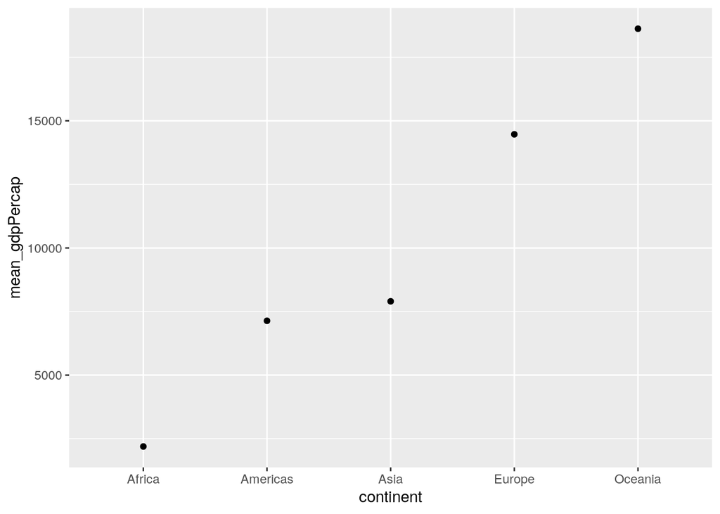

```r
gapminder %>%
  group_by(continent) %>%
  summarize(mean_gdpPercap = mean(gdpPercap)) %>%
  ggplot(mapping = aes(x = continent, y = mean_gdpPercap)) +
  geom_point()
```

That allowed us to calculate the mean `gdpPercap` for each continent, but it gets even better.

## **Challenge 2.**

### Assignment

> - Calculate the average life expectancy per country in Asia. Which has the longest average life expectancy and which has the shortest average life expectancy?

### Solution

```r
gapminder %>%
  filter(continent == "Asia") %>%
  group_by(country) %>%
  summarize(mean_lifeExp = mean(lifeExp)) %>%
  filter(mean_lifeExp == min(mean_lifeExp) | mean_lifeExp == max(mean_lifeExp))
```

```
## # A tibble: 2 x 2
##   country     mean_lifeExp
##   <fct>              <dbl>
## 1 Afghanistan         37.5
## 2 Japan               74.8
```

## More grouping

The function `group_by()` allows us to group by multiple variables. Let’s group by year and continent.

```r
gapminder %>%
  group_by(continent, year) %>%
  summarize(mean_gdpPercap = mean(gdpPercap))
```

```
## # A tibble: 60 x 3
## # Groups:   continent [5]
##    continent  year mean_gdpPercap
##    <fct>     <int>          <dbl>
##  1 Africa     1952          1253.
##  2 Africa     1957          1385.
##  3 Africa     1962          1598.
##  4 Africa     1967          2050.
##  5 Africa     1972          2340.
##  6 Africa     1977          2586.
##  7 Africa     1982          2482.
##  8 Africa     1987          2283.
##  9 Africa     1992          2282.
## 10 Africa     1997          2379.
## # … with 50 more rows
```

That is already quite powerful, but it gets even better! You’re not limited to defining one new variable in `summarize()`.

```r
gapminder %>%
  group_by(continent, year) %>%
  summarize(mean_gdpPercap = mean(gdpPercap),
            sd_gdpPercap = sd(gdpPercap),
            mean_pop = mean(pop),
            sd_pop = sd(pop))
```

```
## # A tibble: 60 x 6
## # Groups:   continent [5]
##    continent  year mean_gdpPercap sd_gdpPercap  mean_pop    sd_pop
##    <fct>     <int>          <dbl>        <dbl>     <dbl>     <dbl>
##  1 Africa     1952          1253.         983.  4570010.  6317450.
##  2 Africa     1957          1385.        1135.  5093033.  7076042.
##  3 Africa     1962          1598.        1462.  5702247.  7957545.
##  4 Africa     1967          2050.        2848.  6447875.  8985505.
##  5 Africa     1972          2340.        3287.  7305376. 10130833.
##  6 Africa     1977          2586.        4142.  8328097. 11585184.
##  7 Africa     1982          2482.        3243.  9602857. 13456243.
##  8 Africa     1987          2283.        2567. 11054502. 15277484.
##  9 Africa     1992          2282.        2644. 12674645. 17562719.
## 10 Africa     1997          2379.        2821. 14304480. 19873013.
## # … with 50 more rows
```

## Using `mutate()`

We can also create new variables prior to (or even after) summarizing information using `mutate()`.

```r
gapminder %>%
  mutate(gdp_billion = gdpPercap * pop / 10^9)
```

```
## # A tibble: 1,704 x 7
##    country     continent  year lifeExp      pop gdpPercap gdp_billion
##    <fct>       <fct>     <int>   <dbl>    <int>     <dbl>       <dbl>
##  1 Afghanistan Asia       1952    28.8  8425333      779.        6.57
##  2 Afghanistan Asia       1957    30.3  9240934      821.        7.59
##  3 Afghanistan Asia       1962    32.0 10267083      853.        8.76
##  4 Afghanistan Asia       1967    34.0 11537966      836.        9.65
##  5 Afghanistan Asia       1972    36.1 13079460      740.        9.68
##  6 Afghanistan Asia       1977    38.4 14880372      786.       11.7
##  7 Afghanistan Asia       1982    39.9 12881816      978.       12.6
##  8 Afghanistan Asia       1987    40.8 13867957      852.       11.8
##  9 Afghanistan Asia       1992    41.7 16317921      649.       10.6
## 10 Afghanistan Asia       1997    41.8 22227415      635.       14.1
## # … with 1,694 more rows
```

```r
gapminder %>%
  mutate(gdp_billion = gdpPercap * pop / 10^9) %>%
  group_by(continent, year) %>%
  summarize(mean_gdpPercap = mean(gdpPercap),
            sd_gdpPercap = sd(gdpPercap),
            mean_pop = mean(pop),
            sd_pop = sd(pop),
            mean_gdp_billion = mean(gdp_billion),
            sd_gdp_billion = sd(gdp_billion))
```

```
## # A tibble: 60 x 8
## # Groups:   continent [5]
##    continent  year mean_gdpPercap sd_gdpPercap mean_pop sd_pop
##    <fct>     <int>          <dbl>        <dbl>    <dbl>  <dbl>
##  1 Africa     1952          1253.         983.   4.57e6 6.32e6
##  2 Africa     1957          1385.        1135.   5.09e6 7.08e6
##  3 Africa     1962          1598.        1462.   5.70e6 7.96e6
##  4 Africa     1967          2050.        2848.   6.45e6 8.99e6
##  5 Africa     1972          2340.        3287.   7.31e6 1.01e7
##  6 Africa     1977          2586.        4142.   8.33e6 1.16e7
##  7 Africa     1982          2482.        3243.   9.60e6 1.35e7
##  8 Africa     1987          2283.        2567.   1.11e7 1.53e7
##  9 Africa     1992          2282.        2644.   1.27e7 1.76e7
## 10 Africa     1997          2379.        2821.   1.43e7 1.99e7
## # … with 50 more rows, and 2 more variables: mean_gdp_billion <dbl>,
## #   sd_gdp_billion <dbl>
```

## **Challenge 3.**

### Assignment

> - Calculate the average life expectancy and GDP (in billions) in 1987 for each continent.

### Solution

```r
gapminder %>%
  mutate(gdp_billion = gdpPercap * pop / 10^9) %>%
  filter(year == 1987) %>%
  group_by(continent) %>%
  summarize(mean_lifeExp = mean(lifeExp),
            mean_gdp_billion = mean(gdp_billion))
```

```
## # A tibble: 5 x 3
##   continent mean_lifeExp mean_gdp_billion
##   <fct>            <dbl>            <dbl>
## 1 Africa            53.3             24.1
## 2 Americas          68.1            439.
## 3 Asia              64.9            242.
## 4 Europe            73.6            317.
## 5 Oceania           75.3            209.
```

## Using `dplyr` and `ggplot2` to visualize average global life expectancy

We will now demonstrate how to use functions from both `dplyr`and `ggplot2` to visualize the average life expectancy of countries that are part of the `gapminder` data set.

First, we need to calculate the average life expectancy for each country using the `summarize()` function:

```r
gapminder_country_summary <- gapminder %>%
  group_by(country) %>%
  summarize(mean_lifeExp = mean(lifeExp))
gapminder_country_summary
```

```
## # A tibble: 142 x 2
##    country     mean_lifeExp
##    <fct>              <dbl>
##  1 Afghanistan         37.5
##  2 Albania             68.4
##  3 Algeria             59.0
##  4 Angola              37.9
##  5 Argentina           69.1
##  6 Australia           74.7
##  7 Austria             73.1
##  8 Bahrain             65.6
##  9 Bangladesh          49.8
## 10 Belgium             73.6
## # … with 132 more rows
```

Next, we will re-use a map introduced in `ggplot` lesson to align with the average life expectancy data from above. We can merge this data with out own, by ensuring the map data has a *common variables* as our statistics data file from gapminder. In this case, our world map has a column called `NAME` that corresponds with a column in the gapminder data called `country`, so we just indicate this in the `by` argument and merge the two data sets together. We can then plot different aesthetics on the map, based on the data from gampinder.

```r
# install.packages("rnaturalearth")
library(sf)
world_map <- rnaturalearth::ne_countries(returnclass = "sf")
gapminder_map <- right_join(gapminder_country_summary, world_map, by=c("country"="name"))
```

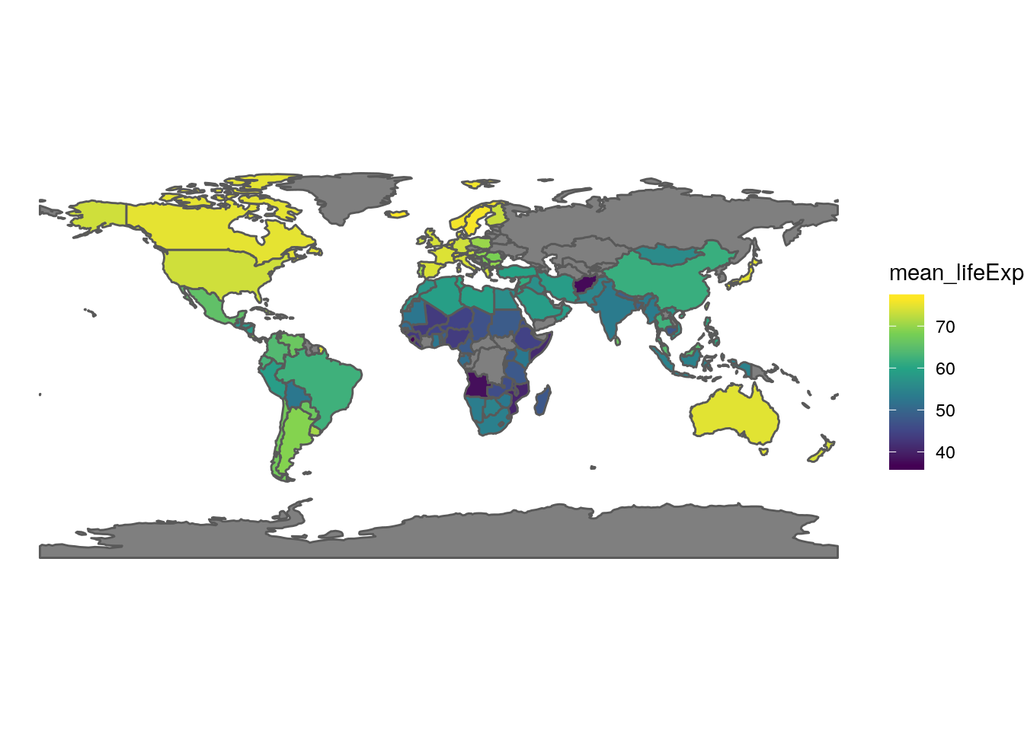

```r
ggplot(gapminder_map) +
  geom_sf(aes(fill = mean_lifeExp, geometry=geometry))+
  scale_fill_viridis_c()+
  theme_void()+
  coord_sf()
```

Note that “grey” countries are not part of `gapminder` or appear under a different name and hence only appear as `NA`’s.

# Key Points

- Use the `dplyr` package to manipulate data
- Use `select()` to choose variables from data
- Use `filter()` to choose data based on values
- Use `group_by()` and `summarize()` to work with subsets of data
- Use `mutate()` to create new variables